# DS311 - R Lab Assignment

2023-04-08

## R Assignment 1

- In this assignment, we are going to apply some of the build in data set in R for descriptive statistics analysis.
- To earn full grade in this assignment, students need to complete the coding tasks for each question to get the result.
- After finished all the questions, knit the document into HTML format for submission.

### Question 1

Using the **mtcars** data set in R, please answer the following questions.

```r
# Loading the data
data(mtcars)

# Head of the data set
head(mtcars)
```

|  | mpg | cyl | disp | hp | drat | wt | qsec | vs | am | gear | carb |
| --- | --- | --- | --- | --- | --- | --- | --- | --- | --- | --- | --- |
| Mazda RX4 | 21.0 | 6 | 160 | 110 | 3.90 | 2.620 | 16.46 | 0 | 1 | 4 | 4 |
| Mazda RX4 Wag | 21.0 | 6 | 160 | 110 | 3.90 | 2.875 | 17.02 | 0 | 1 | 4 | 4 |
| Datsun 710 | 22.8 | 4 | 108 | 93 | 3.85 | 2.320 | 18.61 | 1 | 1 | 4 | 1 |
| Hornet 4 Drive | 21.4 | 6 | 258 | 110 | 3.08 | 3.215 | 19.44 | 1 | 0 | 3 | 1 |
| Hornet Sportabout | 18.7 | 8 | 360 | 175 | 3.15 | 3.440 | 17.02 | 0 | 0 | 3 | 2 |
| Valiant | 18.1 | 6 | 225 | 105 | 2.76 | 3.460 | 20.22 | 1 | 0 | 3 | 1 |

1. Report the number of variables and observations in the data set.

```r
# Enter your code here!
nrow(mtcars)
```

```
## [1] 32
```

```r
ncol(mtcars)
```

```
## [1] 11
```

```r
# Answer:
print("There are total of 11 variables and 32 observations in this data set.")
```

```
## [1] "There are total of 11 variables and 32 observations in this data set."
```

2. Print the summary statistics of the data set and report how many discrete and continuous variables are in the data set.

```r
# Enter your code here!
summary(mtcars)
```

```
##       mpg             cyl             disp             hp
##  Min.   :10.40   Min.   :4.000   Min.   : 71.1   Min.   : 52.0
##  1st Qu.:15.43   1st Qu.:4.000   1st Qu.:120.8   1st Qu.: 96.5
##  Median :19.20   Median :6.000   Median :196.3   Median :123.0
##  Mean   :20.09   Mean   :6.188   Mean   :230.7   Mean   :146.7
##  3rd Qu.:22.80   3rd Qu.:8.000   3rd Qu.:326.0   3rd Qu.:180.0
##  Max.   :33.90   Max.   :8.000   Max.   :472.0   Max.   :335.0
##       drat             wt             qsec             vs
##  Min.   :2.760   Min.   :1.513   Min.   :14.50   Min.   :0.0000
##  1st Qu.:3.080   1st Qu.:2.581   1st Qu.:16.89   1st Qu.:0.0000
##  Median :3.695   Median :3.325   Median :17.71   Median :0.0000
##  Mean   :3.597   Mean   :3.217   Mean   :17.85   Mean   :0.4375
##  3rd Qu.:3.920   3rd Qu.:3.610   3rd Qu.:18.90   3rd Qu.:1.0000
##  Max.   :4.930   Max.   :5.424   Max.   :22.90   Max.   :1.0000
##        am              gear            carb
##  Min.   :0.0000   Min.   :3.000   Min.   :1.000
##  1st Qu.:0.0000   1st Qu.:3.000   1st Qu.:2.000
##  Median :0.0000   Median :4.000   Median :2.000
##  Mean   :0.4062   Mean   :3.688   Mean   :2.812
##  3rd Qu.:1.0000   3rd Qu.:4.000   3rd Qu.:4.000
##  Max.   :1.0000   Max.   :5.000   Max.   :8.000
```

```r
library(magrittr)
mtcars %>% summary()
```

```
##       mpg             cyl             disp             hp
##  Min.   :10.40   Min.   :4.000   Min.   : 71.1   Min.   : 52.0
##  1st Qu.:15.43   1st Qu.:4.000   1st Qu.:120.8   1st Qu.: 96.5
##  Median :19.20   Median :6.000   Median :196.3   Median :123.0
##  Mean   :20.09   Mean   :6.188   Mean   :230.7   Mean   :146.7
##  3rd Qu.:22.80   3rd Qu.:8.000   3rd Qu.:326.0   3rd Qu.:180.0
##  Max.   :33.90   Max.   :8.000   Max.   :472.0   Max.   :335.0
##       drat             wt             qsec             vs
##  Min.   :2.760   Min.   :1.513   Min.   :14.50   Min.   :0.0000
##  1st Qu.:3.080   1st Qu.:2.581   1st Qu.:16.89   1st Qu.:0.0000
##  Median :3.695   Median :3.325   Median :17.71   Median :0.0000
##  Mean   :3.597   Mean   :3.217   Mean   :17.85   Mean   :0.4375
##  3rd Qu.:3.920   3rd Qu.:3.610   3rd Qu.:18.90   3rd Qu.:1.0000
##  Max.   :4.930   Max.   :5.424   Max.   :22.90   Max.   :1.0000
##        am              gear            carb
##  Min.   :0.0000   Min.   :3.000   Min.   :1.000
##  1st Qu.:0.0000   1st Qu.:3.000   1st Qu.:2.000
##  Median :0.0000   Median :4.000   Median :2.000
##  Mean   :0.4062   Mean   :3.688   Mean   :2.812
##  3rd Qu.:1.0000   3rd Qu.:4.000   3rd Qu.:4.000
##  Max.   :1.0000   Max.   :5.000   Max.   :8.000
```

```r
# Answer:
print("There are 5 discrete variables and 6 continuous variables in this data set.")
```

```
## [1] "There are 5 discrete variables and 6 continuous variables in this data set."
```

3. Calculate the mean, variance, and standard deviation for the variable **mpg** and assign them into variable names m, v, and s. Report the results in the print statement.

```r
# Enter your code here!
m = mean(mtcars$mpg)
v = var(mtcars$mpg)
s = sd(mtcars$mpg)

print(paste("The average of Mile Per Gallon from this data set is ", m , " with variance ", v , " and standard deviation", s , "."))
```

```
## [1] "The average of Mile Per Gallon from this data set is  20.090625  with variance  36.3241028225806  and standard deviation 6.0269480520891 ."
```

4. Create two tables to summarize 1) average mpg for each cylinder class and 2) the standard deviation of mpg for each gear class.

```r
# Enter your code here!
library(plyr)
library(dplyr)
cyl_avg_mpg =
  mtcars %>%
  group_by(cyl) %>%
  summarise(AvgMpg=mean(mpg))

gear_avg_mpg =
  mtcars %>%
  group_by(gear) %>%
  summarise(AvgMpg=mean(mpg))

cyl_avg_mpg
```

| cyl | AvgMpg |
| --- | --- |
| 4 | 26.66364 |
| 6 | 19.74286 |
| 8 | 15.10000 |

```r
gear_avg_mpg
```

| gear | AvgMpg |
| --- | --- |
| 3 | 16.10667 |
| 4 | 24.53333 |
| 5 | 21.38000 |

5. Create a crosstab that shows the number of observations belong to each cylinder and gear class combinations. The table should show how many observations given the car has 4 cylinders with 3 gears, 4 cylinders with 4 gears, etc. Report which combination is recorded in this data set and how many observations for this type of car.

```r
# Enter your code here!
observe_by_cyl_gear =
  mtcars %>%
  group_by(cyl, gear) %>%
  count()

print("The most common car type in this data set is car with 8 cylinders and 3 gears. There are total of 12 cars belong to this specification in the data set.")
```

[output not shown]

```
## [1] "The most common car type in this data set is car with 8 cylinders and 3 gears. There are total of 12 cars belong to this specification in the data set."
```

### Question 2

Use different visualization tools to summarize the data sets in this question.

1. Using the **PlantGrowth** data set, visualize and compare the weight of the plant in the three separated group. Give labels to the title, x-axis, and y-axis on the graph. Write a paragraph to summarize your findings.

```r
# Load the data set
data("PlantGrowth")

# Head of the data set
head(PlantGrowth)
```

|  | weight | group |
| --- | --- | --- |
| 1 | 4.17 | ctrl |
| 2 | 5.58 | ctrl |
| 3 | 5.18 | ctrl |
| 4 | 6.11 | ctrl |
| 5 | 4.50 | ctrl |
| 6 | 4.61 | ctrl |

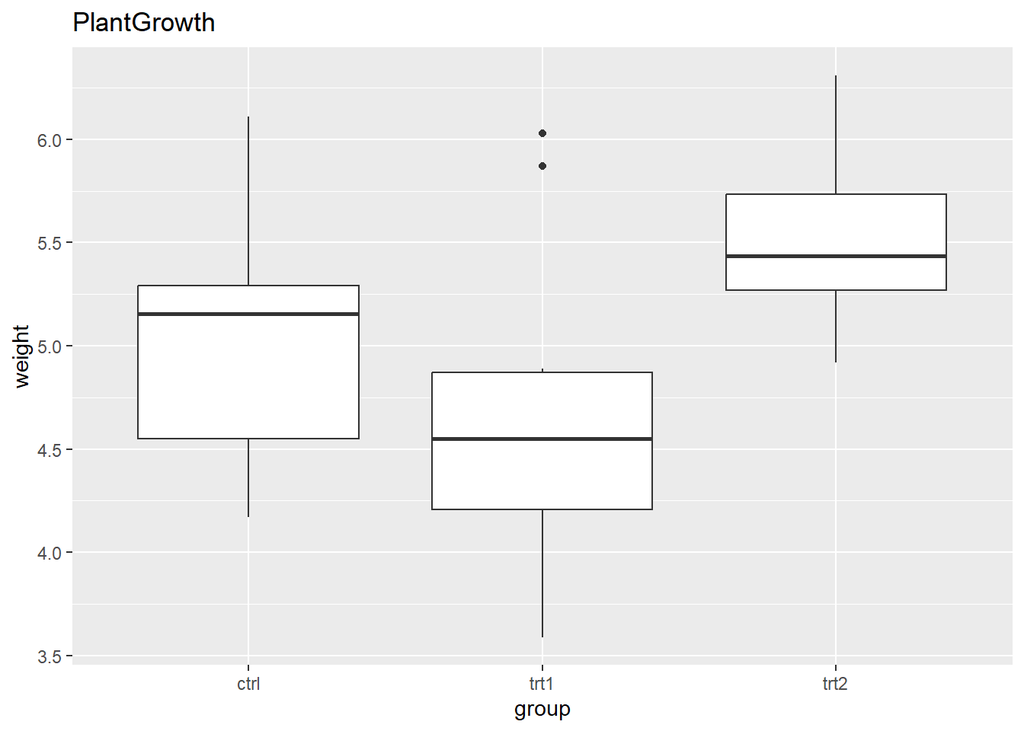

```r
# Enter your code here!
library(ggplot2)
g_plantgrowth = ggplot(data=PlantGrowth) + geom_boxplot(aes(x=group, y=weight))
g_plantgrowth = g_plantgrowth + labs(title="PlantGrowth", x="group", y="weight")
g_plantgrowth
```

Result:

=> Report a paragraph to summarize your findings from the plot!

The graph shows the trt2 group has the best value of mean, max, min, and range. Therefor, the trt2 group has the best result.

2. Using the **mtcars** data set, plot the histogram for the column **mpg** with 10 breaks. Give labels to the title, x-axis, and y-axis on the graph. Report the most observed mpg class from the data set.

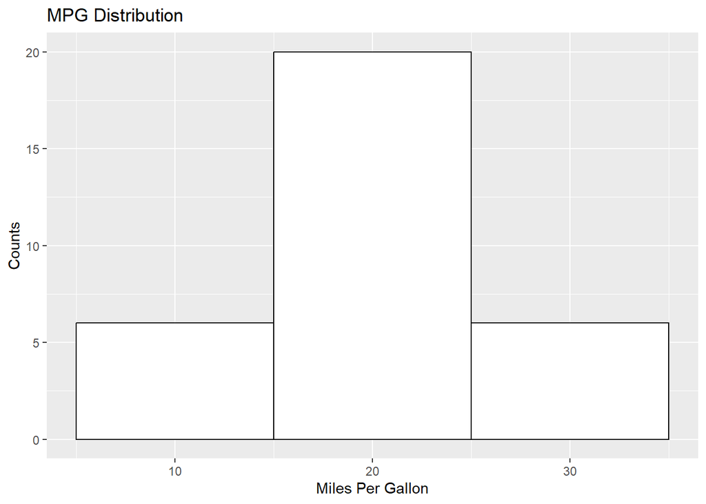

```r
g_mtcars = ggplot(data=mtcars) + geom_histogram(aes(x=mpg), colour="black", fill="white", binwidth = 10)
g_mtcars = g_mtcars + labs(title = "MPG Distribution", x="Miles Per Gallon", y="Counts")
g_mtcars
```

```r
print("Most of the cars in this data set are in the class of 20 mile per gallon.")
```

```
## [1] "Most of the cars in this data set are in the class of 20 mile per gallon."
```

```r
# Load the data set
data("USArrests")

# Head of the data set
head(USArrests)
```

|  | Murder | Assault | UrbanPop | Rape |
| --- | --- | --- | --- | --- |
| Alabama | 13.2 | 236 | 58 | 21.2 |
| Alaska | 10.0 | 263 | 48 | 44.5 |
| Arizona | 8.1 | 294 | 80 | 31.0 |
| Arkansas | 8.8 | 190 | 50 | 19.5 |
| California | 9.0 | 276 | 91 | 40.6 |
| Colorado | 7.9 | 204 | 78 | 38.7 |

```r
# Enter your code here!
library(ggrepel)
```

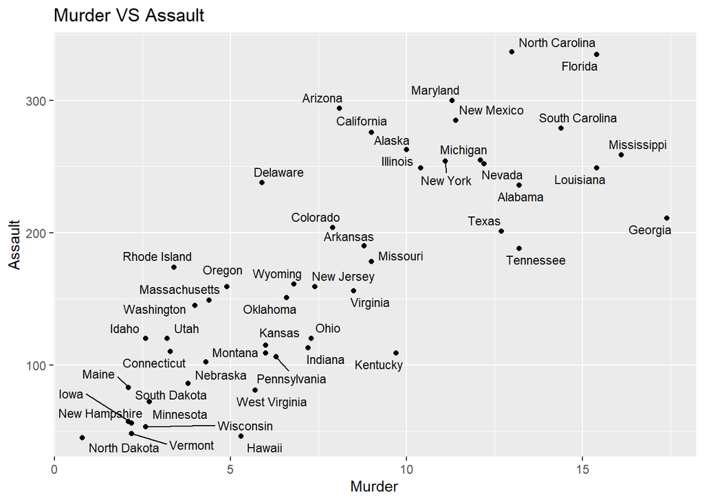

```r
g_usarrests = ggplot(USArrests, aes(x=Murder, y=Assault, label=rownames(USArrests))) + geom_point()
g_usarrests = g_usarrests + labs(title="Murder VS Assault", x="Murder", y="Assault")
g_usarrests = g_usarrests + geom_text_repel(size=3)
g_usarrests
```

Result:

=> Report a paragraph to summarize your findings from the plot!

The graph shows the states with more murder cases have more assault cases.

### Question 3

Download the housing data set from www.jaredlander.com and find out what explains the housing prices in New York City.

Note: Check your working directory to make sure that you can download the data into the data folder.

1. Create your own descriptive statistics and aggregation tables to summarize the data set and find any meaningful results between different variables in the data set.

```r
# Head of the cleaned data set
head(housingData)
```

|  | Neighborhood | Market.Value.per.SqFt | Boro | Year.Built |
| --- | --- | --- | --- | --- |
| 1 | FINANCIAL | 200.00 | Manhattan | 1920 |
| 2 | FINANCIAL | 242.76 | Manhattan | 1985 |
| 4 | FINANCIAL | 271.23 | Manhattan | 1930 |
| 5 | TRIBECA | 247.48 | Manhattan | 1985 |
| 6 | TRIBECA | 191.37 | Manhattan | 1986 |
| 7 | TRIBECA | 211.53 | Manhattan | 1985 |

```r
# Enter your code here!
summary(housingData)
```

```
##  Neighborhood       Market.Value.per.SqFt     Boro             Year.Built
##  Length:2530        Min.   : 10.66        Length:2530        Min.   :1825
##  Class :character   1st Qu.: 75.10        Class :character   1st Qu.:1926
##  Mode  :character   Median :114.89        Mode  :character   Median :1986
##                     Mean   :133.17                           Mean   :1967
##                     3rd Qu.:189.91                           3rd Qu.:2005
##                     Max.   :399.38                           Max.   :2010
```

```r
count_neighborhood = housingData %>% group_by(Neighborhood) %>% count()
count_boro = housingData %>% group_by(Boro) %>% count()
count_builtyear = housingData %>% group_by(Year.Built) %>% count()
count_builtyear_boro_neighborhood = housingData %>% group_by(Year.Built, Boro, Neighborhood) %>% count()
count_neighborhood
```

| Neighborhood | n |
| --- | --- |
| ALPHABET CITY | 24 |
| ARROCHAR-SHORE ACRES | 1 |
| ASTORIA | 30 |
| BATH BEACH | 6 |
| BAY RIDGE | 8 |
| BAYSIDE | 9 |
| BEDFORD PARK/NORWOOD | 2 |
| BEDFORD STUYVESANT | 58 |
| BELMONT | 1 |
| BENSONHURST | 7 |

[output cut: 138 more lines]

```r
count_boro
```

| Boro | n |
| --- | --- |
| Bronx | 69 |
| Brooklyn | 626 |
| Manhattan | 1379 |
| Queens | 432 |
| Staten Island | 24 |

```r
count_builtyear
```

| Year.Built | n |
| --- | --- |
| 1825 | 1 |
| 1836 | 1 |
| 1853 | 1 |
| 1860 | 2 |
| 1874 | 1 |
| 1875 | 2 |
| 1879 | 2 |
| 1881 | 2 |
| 1883 | 1 |
| 1890 | 4 |

[output cut: 114 more lines]

```r
count_builtyear_boro_neighborhood
```

| Year.Built | Boro | Neighborhood | n |
| --- | --- | --- | --- |
| 1825 | Brooklyn | COBBLE HILL | 1 |
| 1836 | Manhattan | FINANCIAL | 1 |
| 1853 | Manhattan | TRIBECA | 1 |
| 1860 | Manhattan | CIVIC CENTER | 2 |
| 1874 | Manhattan | SOHO | 1 |
| 1875 | Manhattan | CHELSEA | 1 |
| 1875 | Manhattan | TRIBECA | 1 |
| 1879 | Manhattan | SOHO | 2 |
| 1881 | Manhattan | HARLEM-CENTRAL | 1 |
| 1881 | Manhattan | SOHO | 1 |

[output cut: 1315 more lines]

2. Create multiple plots to demonstrates the correlations between different variables. Remember to label all axes and give title to each graph.

[figure not shown]

```r
# Enter your code here!
bulityear_MVPS_TRIBECA = housingData[housingData$Neighborhood %in% "TRIBECA",]
bulityear_MVPS_TRIBECA = ggplot(bulityear_MVPS_TRIBECA, aes(x=Year.Built, y=Market.Value.per.SqFt)) + geom_point()
bulityear_MVPS_TRIBECA = bulityear_MVPS_TRIBECA + geom_smooth(method=lm)
bulityear_MVPS_TRIBECA = bulityear_MVPS_TRIBECA + labs(title="Market Value Per Square Foot VS Built Year in Financial", x="Built Year", y="Market Value Per Square Feet")
bulityear_MVPS_TRIBECA
```

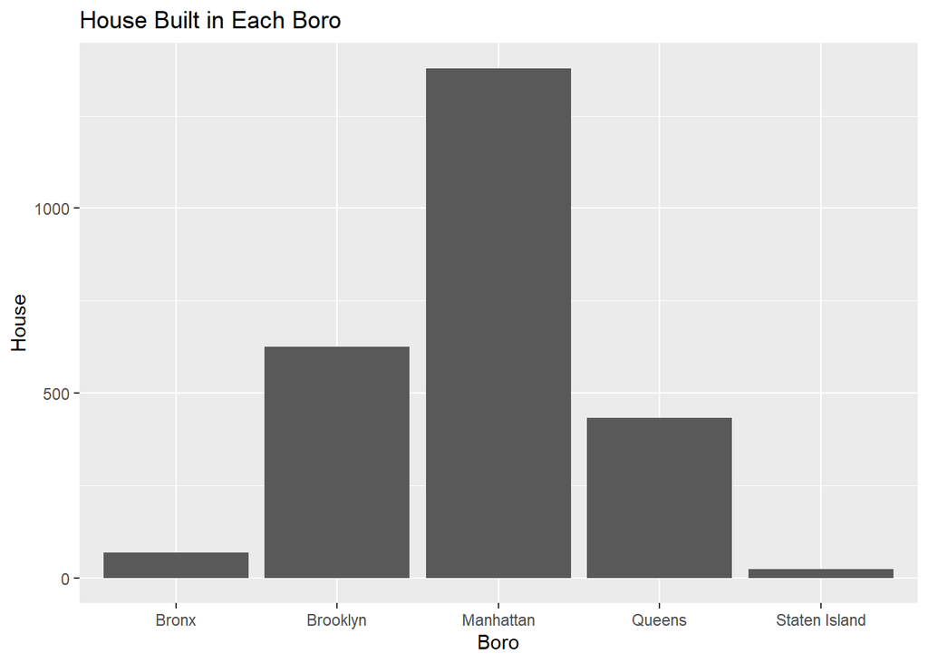

```r
g_built_boro = ggplot(count_boro, aes(Boro, n)) + geom_bar(stat="identity")
g_built_boro = g_built_boro + labs(title="House Built in Each Boro", x="Boro", y="House")
g_built_boro
```

3. Write a summary about your findings from this exercise.